# Day 24 - Advanced Git

Fall 2022

[Dr. Jared Joseph](https://jnjoseph.com/)

November 06, 2022

## Overview

### Timeline

- git Recap
- git in the Terminal
- Advanced git
- Advanced Github

### Goal

Learn how to use git to effectively collaborate

# git Recap

## git as Timelines

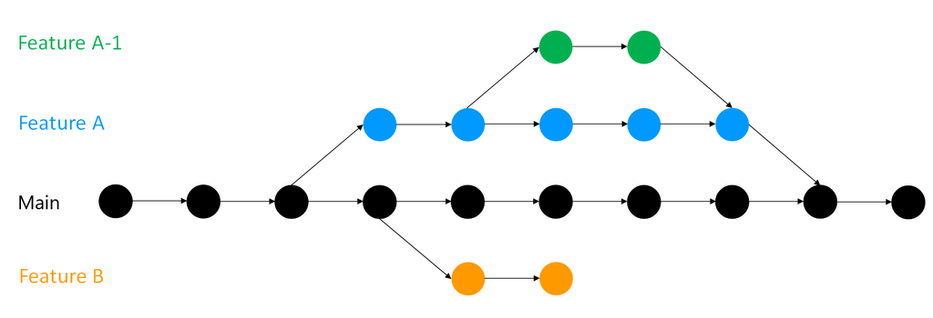

The Turing Way

## git Workflow

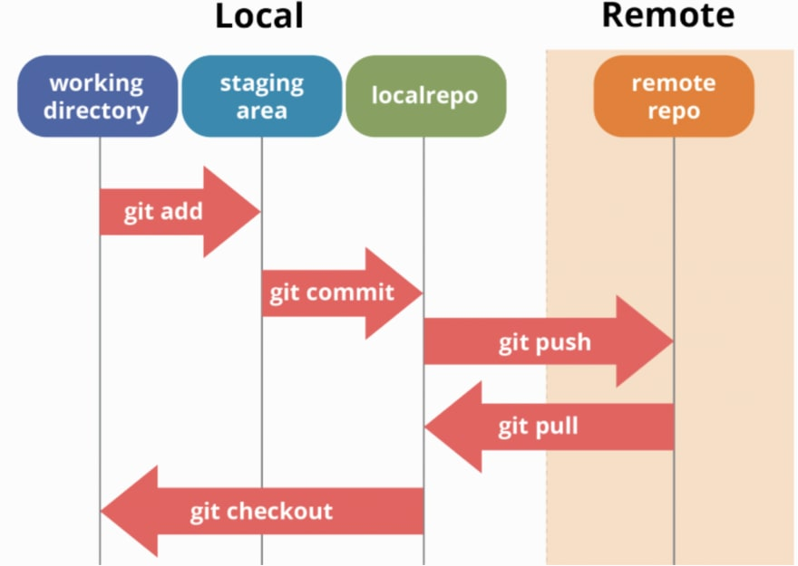

# git in the Terminal

## Key Terms

**repo**

Repository - the collection of git files that contain your project

**commit**

To save a checkpoint of your project for future reference

**revert**

Undo all changes made to a file since the last commit

**staged**

A file that is preparing to be commited, but has not yet been

**push**

To ‘push’ files from your local machine onto an internet service

**pull**

To ‘pull’ files from a remote service onto your machine

**merge**

To combine two branches/files of the same project

**conflict**

When two files or set of files have changes that cannot be easily merged

**checkout**

Load in a previous checkpoint (commit) or switch to a branch

## git Commands

**git status**

Check the staging area and what branch you are on.

**git add <FILES>**

Add a file to the staging area

**git commit -m “COMMIT MESSAGE”**

To save a checkpoint of your project for future reference

**git revert <FILES>**

Undo all changes made to a file since the last commit

**git push**

To ‘push’ files from your local machine onto an internet service

**git pull**

To ‘pull’ files from a remote service onto your machine

**git merge <BRANCH NAME>**

To combine two branches branches. It will merge the branch you name into your current branch.

**git checkout <BRANCH NAME>**

Load in a previous checkpoint (commit) or switch to a branch. Use the “-B” flag to create this branch at the same time.

# Advanced git

## git Ignore

The hidden `.gitignore` file lets you tell git “I do not want you to pay attention to these files or folders.”

This can be very handy if you want to:

- Ignore all `.csv` files
- Ignore your scrap folder
- Ignore the file containing your API keys
- etc

[figure not shown]

## Branches

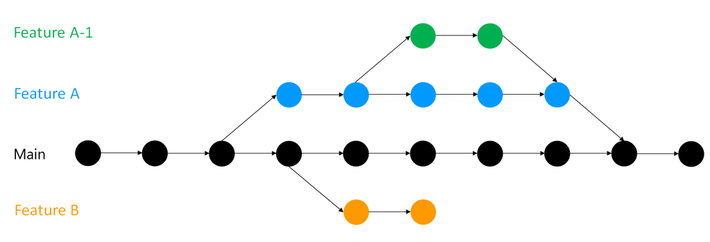

The Turing Way

branch ->

<- merge

**git checkout *<NAME OF BRANCH>**

Switch between branches

**git checkout -B *<NAME OF BRANCH>**

Create new branch and switch to it

**git merge *<NAME OF BRANCH>**

Merge two branches

# Advanced Github

## Issues

[figure not shown]

## Pull Requests and Review

[figure not shown]

## Forking

[figure not shown]

# Code-Along

## For Next Time

### Topic

Lab 6 Review

### To-Do

- Finish Worksheet
- Class Survey

SDS 192-03: Intro to Data Science